# Lab 1 - Introduction to R

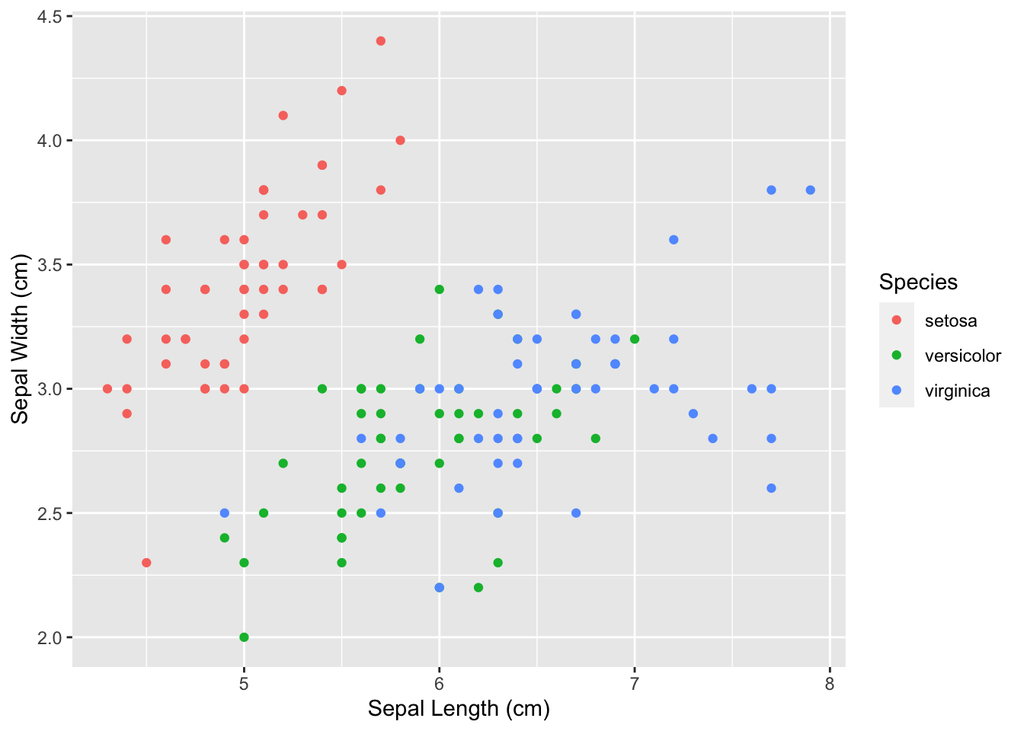

```r
ggplot(data=iris)+
  geom_point(mapping=aes(x=Sepal.Length, y=Sepal.Width, color=Species))+
  labs(x="Sepal Length (cm)", y="Sepal Width (cm)")
```

We can create a more professional plot using the `theme_classic()` aesthetic function.

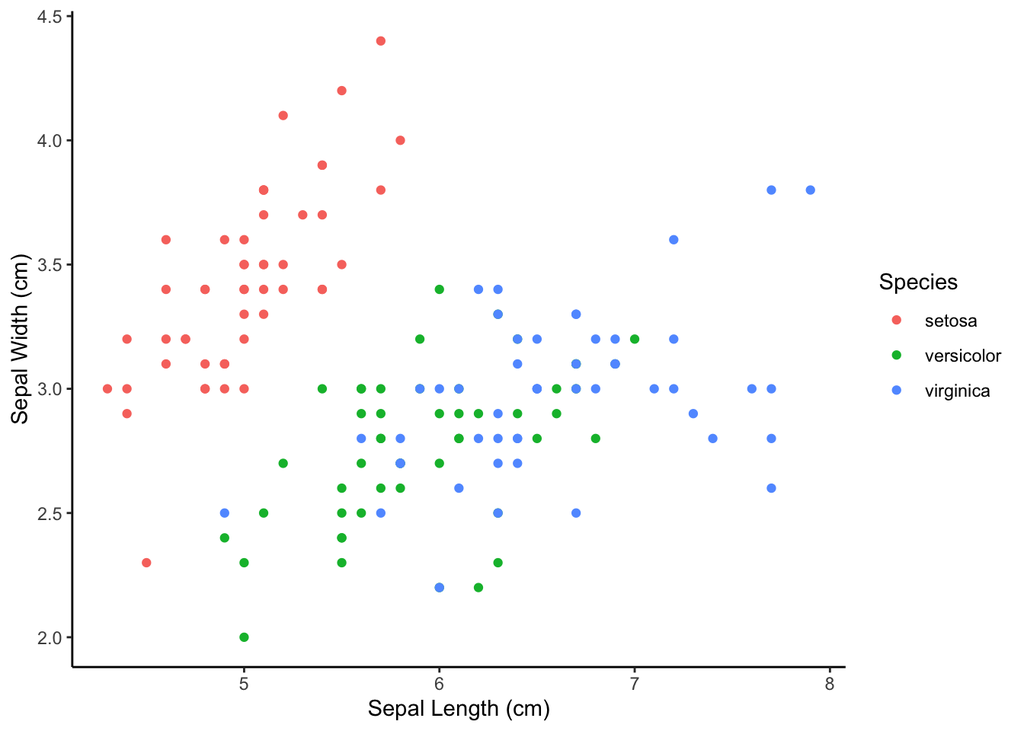

```r
ggplot(data=iris)+
  geom_point(mapping=aes(x=Sepal.Length, y=Sepal.Width, color=Species))+
  labs(x="Sepal Length (cm)", y="Sepal Width (cm)")+
  theme_classic()
```

Lastly, we can add a lines of best fit from linear regression models done by species using the `geom_smooth()`function.

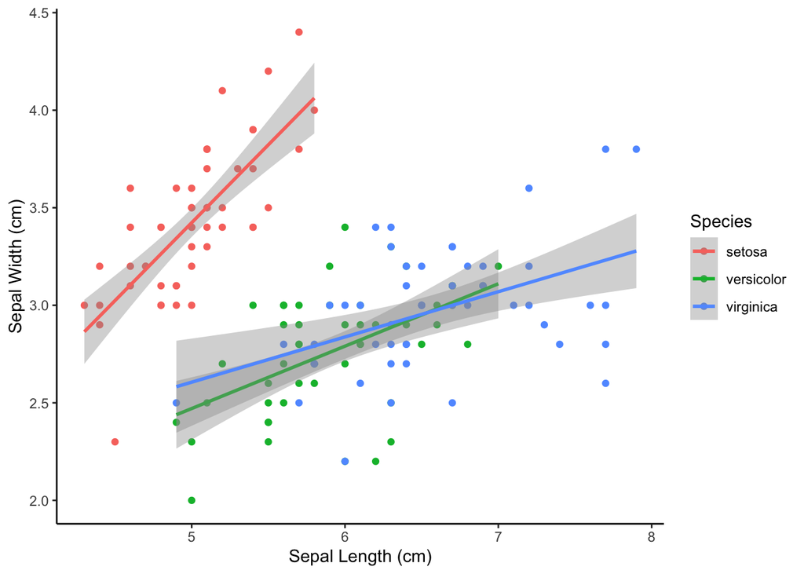

```r
ggplot(data=iris)+
  geom_point(mapping=aes(x=Sepal.Length, y=Sepal.Width, color=Species))+
  labs(x="Sepal Length (cm)", y="Sepal Width (cm)")+
  geom_smooth(aes(x=Sepal.Length, y=Sepal.Width,group=Species, colour=Species), formula ='y ~ x',method="lm")+
  theme_classic()
```

### US Maps

Within R, there are some spatial datasets we can manipulate and plot.

```r
states = as.data.frame(state.x77)
states$region = tolower(rownames(states))
```

ggplot has some map data too.

```r
states_map = map_data("state")
class(states_map)
```

```
## [1] "data.frame"
```

Let’s look to see which states are represented?

```r
unique(states_map$region)
```

```
##  [1] "alabama"              "arizona"              "arkansas"
##  [4] "california"           "colorado"             "connecticut"
##  [7] "delaware"             "district of columbia" "florida"
## [10] "georgia"              "idaho"                "illinois"
## [13] "indiana"              "iowa"                 "kansas"
## [16] "kentucky"             "louisiana"            "maine"
## [19] "maryland"             "massachusetts"        "michigan"
## [22] "minnesota"            "mississippi"          "missouri"
## [25] "montana"              "nebraska"             "nevada"
## [28] "new hampshire"        "new jersey"           "new mexico"
## [31] "new york"             "north carolina"       "north dakota"
## [34] "ohio"                 "oklahoma"             "oregon"
## [37] "pennsylvania"         "rhode island"         "south carolina"
## [40] "south dakota"         "tennessee"            "texas"
## [43] "utah"                 "vermont"              "virginia"
## [46] "washington"           "west virginia"        "wisconsin"
## [49] "wyoming"
```

Let’s merge the two datasets. This merges the *states* data with the spatial information for each state.

```r
fact_join = left_join(states_map, states, by = "region")
```

Let’s map *Life Expectancy in Years (1969–71)* by state.

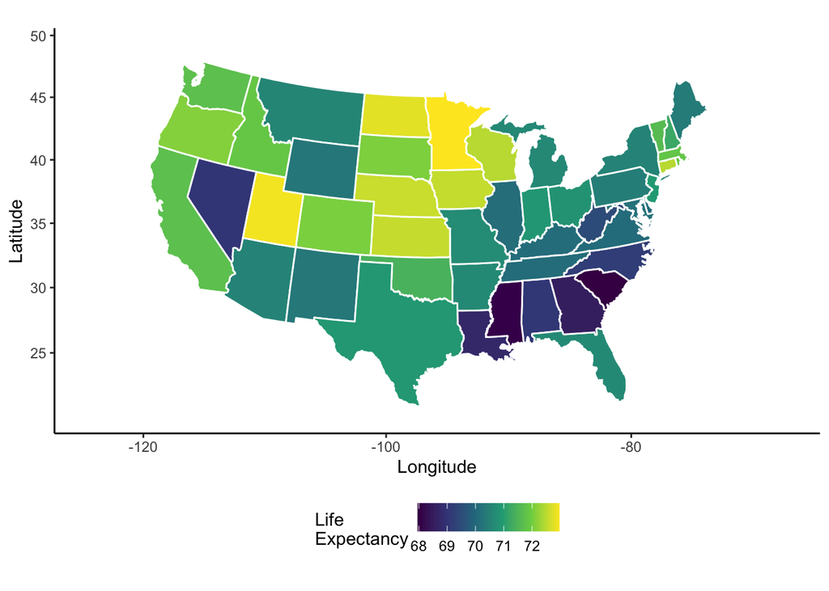

```r
life_expectancy = ggplot(data=fact_join, mapping=aes(x=long, y=lat, group = group))+
  geom_polygon(aes(fill = `Life Exp`), colour = "white")+
  scale_fill_viridis_c(option = "D")+
  theme_classic()+
  coord_map("bonne", lat0 = 40)+
  labs(y = "Latitude", x = "Longitude", fill="Life\nExpectancy")+
  theme(legend.position = "bottom")
print(life_expectancy)
```

Now, let’s map *Murder and non-negligent manslaughter rate per 100,000 population (1976)* by state.

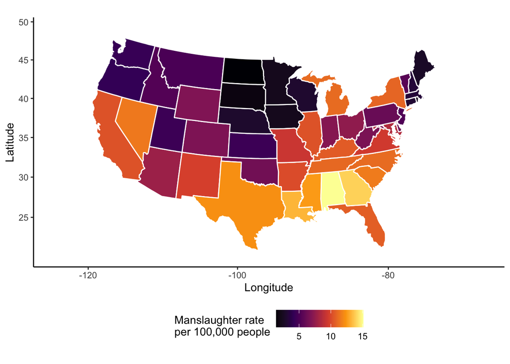

```r
murder = ggplot(fact_join, aes(long, lat, group = group))+
  geom_polygon(aes(fill = Murder), color = "white")+
  scale_fill_viridis_c(option = "B")+
  theme_classic()+
  coord_map("bonne", lat0 = 40)+
  labs(y = "Latitude", x = "Longitude", fill="Manslaughter rate\nper 100,000 people") +
  theme(legend.position = "bottom")
print(murder)
```

We can used the `plot_grid` function to make aggregate plots.

We can make the panel plot either horizontal or vertical by changing the `nrow` attribute.

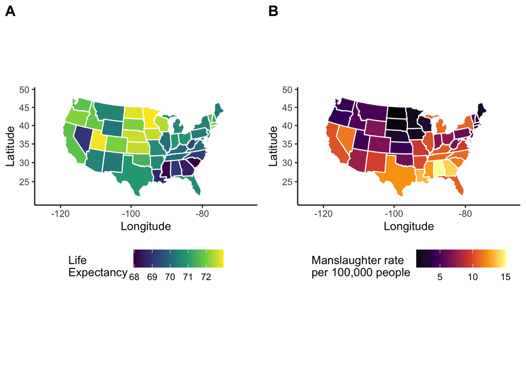

```r
plot_grid(life_expectancy, murder, labels = "AUTO", nrow=1)
```

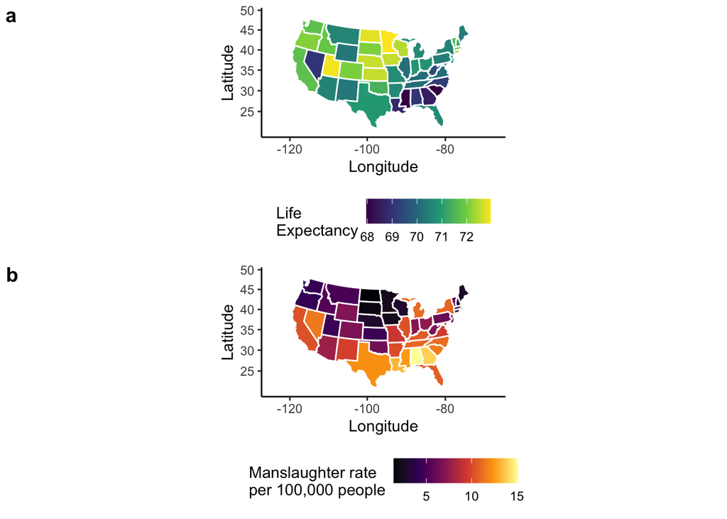

```r
plot_grid(life_expectancy, murder, labels = "auto", ncol=1)
```

### Bring datasets into the R environment.

##### Good data management

1. No spaces within object names (same for names in data files, use . or _ instead).
2. Don’t name an object similar/same as a function (e.g., don’t name your data “data.frame”).
3. Can’t start object names with a number.

##### Import data file

Many ways data can be imported Many types of files can be imported (shape files, text files, csv)

`read.table` reads any table, can specify which format `read.csv` fields are separated by a comma `readxl` reads Micrsoft Excel files

Let’s read in a file containing US college and university geographic information.

```r
us_uni_csv = read.csv("data/universities.csv")
```

From the file we just read in, named `us_uni_csv`, let’s subset the data frame to just *Colorado State University*.

```r
csu = us_uni_csv %>% filter(NAME=="Colorado State University")
print(csu)
```

```
##   IPEDSID                      NAME                       LADDR LADDR2
## 1  126818 Colorado State University 102 Administration Building     NA
##          LCITY LSTATE  LZIP LZIP4 COUNTRY      PHONE STFIPS COFIPS      LAT
## 1 Fort Collins     CO 80523   100      US 9704911101      8   8069 40.57476
##         LON SECTOR LEVEL INST_TYPE NAICS_CODE
## 1 -105.0808      1     1         1     611310
##                                         NAICS_DESC HI_OFFER DEG_GRANT LOCALE
## 1 Colleges, Universities, and Professional Schools       11         1     12
##   STATUS CLOSE_DATE MERGE_ID ALIAS SIZE_SET INST_SIZE PT_ENROLL FT_ENROLL
## 1      A         -2       -2  <NA>       15         5      5585     22211
##   TOT_ENROLL HOUSING DORM_CAP  FTE                          NCES_URL
## 1      27796       1     5240 8473 http://nces.ed.gov/GLOBALLOCATOR/
##          SCHOOL_URL SHELTER_ID LAST_UPDAT
## 1 www.colostate.edu         NA    1/15/10
```

Now, let’s subset to the state of Colorado.

```r
colorado_universities = us_uni_csv %>% filter(LSTATE=="CO")
head(colorado_universities)
```

```
##   IPEDSID                              NAME                    LADDR LADDR2
## 1  126915  Delta Montrose Technical College           1765 US Hwy 50     NA
## 2  127219           Glenwood Beauty Academy 51241 Hwy 6 and 24 Ste 1     NA
## 3  128391 Western State College of Colorado              600 N Adams     NA
## 4  127185                Fort Lewis College           1000 Rim Drive     NA
## 5  126164    The Salon Professional Academy        2938 North Ave #B     NA
## 6  128188 Intellitec College-Grand Junction           772 Horizon Dr     NA
##              LCITY LSTATE  LZIP LZIP4 COUNTRY      PHONE STFIPS COFIPS      LAT
## 1            Delta     CO 81416    NA      US 9708747671      8   8029 38.70252
## 2 Glenwood Springs     CO 81601    NA      US 9709450485      8   8045 39.57547
## 3         Gunnison     CO 81231    NA      US 9709430120      8   8051 38.54742
## 4          Durango     CO 81301  3999      US 9702477010      8   8067 37.27543
## 5   Grand Junction     CO 81504    NA      US 9702451110      8   8077 39.07820
## 6   Grand Junction     CO 81506    NA      US 9702458101      8   8077 39.11635
##         LON SECTOR LEVEL INST_TYPE NAICS_CODE
```

[output cut: 34 more lines]

How many institutions reside in Colorado?

```r
nrow(colorado_universities)
```

```
## [1] 112
```

What else is in this data frame? We see that data frame includes information on the Total Enrollment, e.g.,`$TOT_ENROLL`, and many other pieces of information.

```r
str(colorado_universities)
```

```
## 'data.frame':    112 obs. of  38 variables:
##  $ IPEDSID   : int  126915 127219 128391 127185 126164 128188 127556 128036 126748 126711 ...
##  $ NAME      : chr  "Delta Montrose Technical College" "Glenwood Beauty Academy" "Western State College of Colorado" "Fort Lewis College" ...
##  $ LADDR     : chr  "1765 US Hwy 50" "51241 Hwy 6 and 24 Ste 1" "600 N Adams" "1000 Rim Drive" ...
##  $ LADDR2    : logi  NA NA NA NA NA NA ...
##  $ LCITY     : chr  "Delta" "Glenwood Springs" "Gunnison" "Durango" ...
##  $ LSTATE    : chr  "CO" "CO" "CO" "CO" ...
##  $ LZIP      : int  81416 81601 81231 81301 81504 81506 81501 81328 81648 81601 ...
##  $ LZIP4     : int  NA NA NA 3999 NA NA 3122 9196 3598 233 ...
##  $ COUNTRY   : chr  "US" "US" "US" "US" ...
##  $ PHONE     : chr  "9708747671" "9709450485" "9709430120" "9702477010" ...
##  $ STFIPS    : int  8 8 8 8 8 8 8 8 8 8 ...
##  $ COFIPS    : int  8029 8045 8051 8067 8077 8077 8077 8083 8103 8045 ...
##  $ LAT       : num  38.7 39.6 38.5 37.3 39.1 ...
##  $ LON       : num  -108 -107 -107 -108 -109 ...
```

[output cut: 24 more lines]

You can explore some simple statistics on total enrollment and the other metrics if you follow this link: https://www.sciencebase.gov/catalog/item/4f4e4acee4b07f02db67fb39.

Let’s make a plot of the distribution of the *Total Enrollment* across Colorado institutions of higher education.

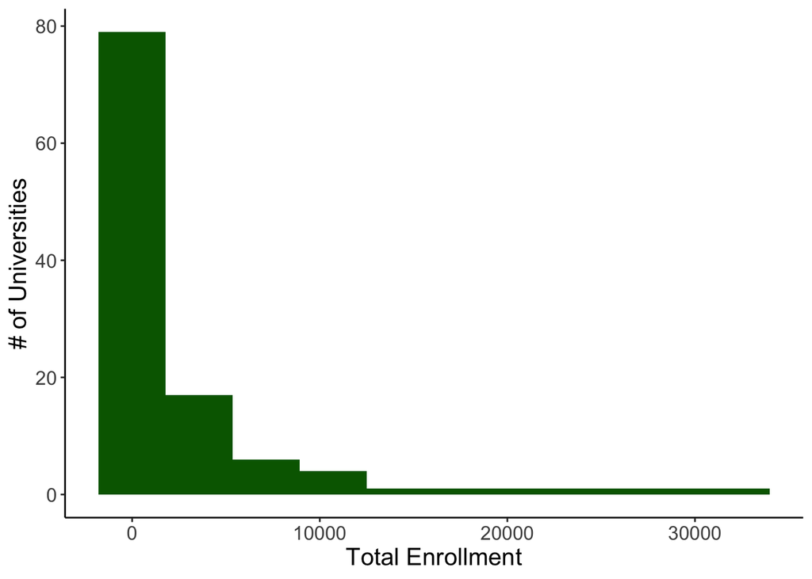

```r
ggplot(data=colorado_universities)+
  geom_histogram(mapping=aes(TOT_ENROLL), bins = 10, fill="darkgreen")+
  theme_classic()+
  labs(y = "# of Universities", x = "Total Enrollment")+
  theme(text = element_text(size=15))
```

We can explore the `range` of enrollment and the determine the `mean`.

```r
range(colorado_universities$TOT_ENROLL)
```

```
## [1]     0 32191
```

```r
mean(colorado_universities$TOT_ENROLL)
```

```
## [1] 2892.384
```

Let’s say we need to share our subset data frame with a collaborator. Currently, our Colorado-specific dataset only lives within R. We need to output the data frame. A common format is a *.csv*, which stands for comma separated values.

```r
write.csv(colorado_universities, "colorado_universities.csv", row.names=F)

#if you're working with large datasets, it's good to use fwrite and fread from the data.table package
```

Let’s make a shapefile of the locations using the `sf` package commands

```r
colorado_universities_shp = st_as_sf(colorado_universities, coords = c("LON", "LAT"), crs = "+proj=longlat +datum=WGS84")
```

Like the previous example, our collaborator needs a shapefile of the Colorado institutions. Let’s fill that request by outputting a shapefile using the `st_write` function.

```r
st_write(colorado_universities_shp, "data/collegesuniversities.shp", driver = "ESRI Shapefile", delete_layer = TRUE)
```

```
## Deleting layer `collegesuniversities' using driver `ESRI Shapefile'
## Writing layer `collegesuniversities' to data source
##   `data/collegesuniversities.shp' using driver `ESRI Shapefile'
## Writing 112 features with 36 fields and geometry type Point.
```

Now, let’s read the shapefile of the Colorado institutions that you just created.

```r
colorado_universities_shp = st_read("data/collegesuniversities.shp")
colorado_universities_shp = st_transform(colorado_universities_shp, "epsg:4326") #this command allows you reproject your shapefile.
```

Read in a Colorado county shapefile

```r
co_counties = st_read("data/colorado_county_boundaries.shp") #this might take a couple of seconds to load
co_counties = st_transform(co_counties, "epsg:4326") #this will transform the coordinates to WGS84
```

```r
colorado_universities_shp = subset(colorado_universities_shp, TOT_ENROLL>1000)
```

Let’s determine the range and save the values. We will use these stored values below for plotting

```r
min_enroll=min(colorado_universities_shp$TOT_ENROLL)
max_enroll=max(colorado_universities_shp$TOT_ENROLL)
```

Use ggplot to map a state map

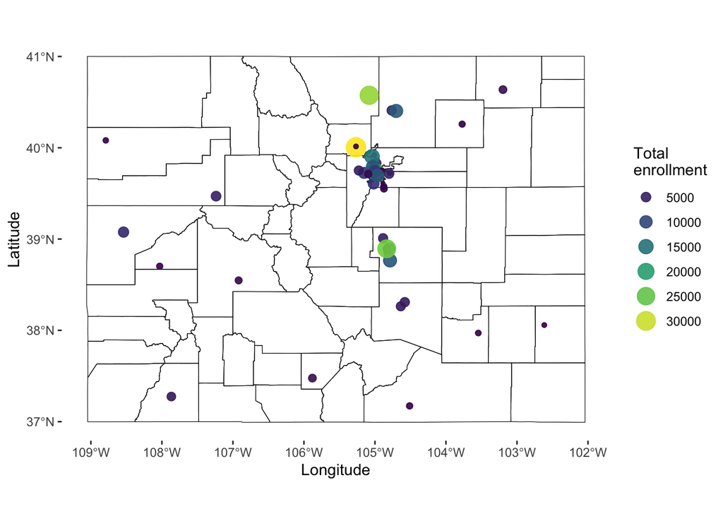

```r
CO_MAP_UNI=ggplot() +
  geom_sf(data = co_counties,  fill = NA, color ="black", lwd=.1) +
  geom_sf(data = colorado_universities_shp, aes(size=TOT_ENROLL, colour=TOT_ENROLL), alpha=.9) +
  theme_bw()+
  theme(panel.grid.minor=element_blank(),panel.grid.major=element_blank())+
  theme( panel.border=element_blank())+
  scale_colour_viridis_c(limits=c(min_enroll, max_enroll), breaks=seq(5000, 30000, by=5000), name = "Total\nenrollment")+
  guides(color= guide_legend(), size=guide_legend())+
  scale_size_continuous(limits=c(min_enroll, max_enroll), breaks=seq(5000, 30000, by=5000),name = "Total\nenrollment")+
  labs(y = "Latitude", x = "Longitude")
CO_MAP_UNI
```